# Reaction Time Behavioral Analysis

Author: Haroon Popal

2024-03-11

# Background

The objective of this study was to examine how non-autistic and autistic process social rewards, and whether participants would be able to learn whether two individuals were more similar or dissimilar to them. Prior to the fMRI scan, participants completed a survey of their interests (e.g. I am an animal lover). Using this survey, with over 200 responses, we matched other real participants to each other, such that every participant had a similar peer which shared 75% of the same interests, and a dissimilar peer which shared only 25% of the same interests. In the fMRI task, participants were shown an individuals name, either Shiloh or Charlie. These were the similar or dissimilar peers. For each trial, participants were first shown the peer’s name, then their own response to a survey question (e.g. animal lover indicating that the participant had responded that they love animals). Next, participants had to press a button to learn about the shown peer. The feedback consisted of a thumbs up with a “Me too!” message or a thumbs down with a “Not me!” message, indicating whether the peer had shared that interest or not. There was also a computer peer condition in which the computer gave 50% positive feedback as a “match” or “no match”.

## Task Design

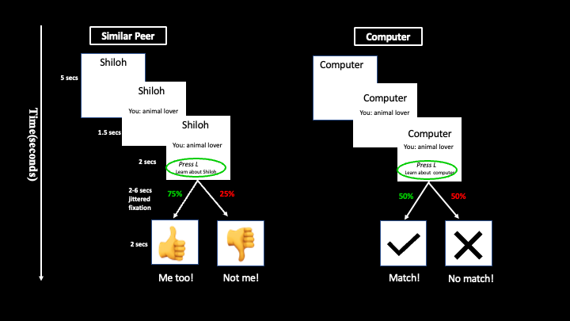

Social Reward Task

This was an event-related design with four runs of the task.

## Setup Up

### Import Packages

```r
library(dplyr)
library(tidyr)
library(ggplot2)
library(emmeans)
library(lmerTest)
require(gridExtra)
```

### Define directories

```r
data_dir <- 'derivatives/task_socialreward/data/'
```

### Find participants

```r
subj_df <- read.csv('participants.tsv', sep = '\t')

# Remove prefix from subject IDs
subj_df$participant_id<-gsub("sub-SCN","SCN_",as.character(subj_df$participant_id))

print(paste('Found ', length(subj_df$participant_id), ' participants'))
```

```
## [1] "Found  85  participants"
```

# Data Cleaning

```r
# Create an empty dataframe to fill with all the participant data
rt_data <- data.frame(matrix(ncol = 4, nrow = 0))

# Name columns for the empty dataframe
colnames(rt_data) <- c('ParticipantID', 'Run', 'ConditionName', 'Correct_RT')


# Import Data

for (subj in subj_df$participant_id) {

  # Find data for all runs
  run_files <- Sys.glob(paste(data_dir, subj, '/*-errors.csv', sep = ''))

  # Loop through runs and combine into one df
  for (run_file in run_files){
    temp_run_data <- read.csv(run_file)

    if (sum(temp_run_data$redcap_v_task) == 0) {

      # Filter for relevant columns
      temp_run_data_fltr <- temp_run_data[,colnames(rt_data)]

      # Append to entire df
      rt_data <- rbind(rt_data, temp_run_data_fltr)
    }
  }
}
```

Add group (e.g. autistic, non-autistic) info to reaction time dataframe

```r
rt_data <- merge(rt_data, subj_df,
                 by.x = 'ParticipantID', by.y = 'participant_id')

# Rename column
rt_data <- rt_data %>% rename_at('ParticipantID', ~'participant_id')
```

Create column for the peer conditions info

```r
rt_data <- rt_data %>% separate(ConditionName, c('Reward_Level', 'Condition'))
```

Make group data an nominal data type

```r
rt_data$group<-gsub('1','non-autistic',as.character(rt_data$group))
rt_data$group<-gsub('2','autistic',as.character(rt_data$group))
head(rt_data)
```

|  | participant_id | Run | Reward_Level | Condition | Correct_RT | group |
| --- | --- | --- | --- | --- | --- | --- |
| 1 | SCN_101 | 1 | LowReward | SimPeer | 0.9623290 | non-autistic |
| 2 | SCN_101 | 1 | LowReward | DisPeer | 0.6395893 | non-autistic |
| 3 | SCN_101 | 1 | HighReward | SimPeer | 0.5847357 | non-autistic |
| 4 | SCN_101 | 1 | LowReward | DisPeer | 0.5628054 | non-autistic |
| 5 | SCN_101 | 1 | LowReward | DisPeer | 0.6831392 | non-autistic |
| 6 | SCN_101 | 1 | HighReward | Computer | 0.5634205 | non-autistic |

## Missed trials

When a participant did not press the correct button, the feedback was “no data”. This occurred in two instances:

- When the participant made no button press
- When the participant hit the incorrect button, and did not hit the correct button before the trial timed out

In both these instances, the participant was not paying attention and so we should exclude these trials. If this was the case for more than 20% of the run, then we should exclude data from the entire run.

```r
# Find participant runs with more than 20% missed trials

exclude_subj_runs <- data.frame(participant_id = character(), Run = character(), stringsAsFactors = FALSE)

# Create a list of all subject IDs
subj_list <- unique(rt_data$participant_id)

for (subj in subj_list) {

  # Filter for subject specific data
  temp_subj_data <- rt_data[rt_data$participant_id == subj, ]

  # Find runs per subject
  temp_runs <- unique(temp_subj_data$Run)

  for (run in temp_runs) {

    # Filter for run specific data
    temp_run_rt <- temp_subj_data[temp_subj_data$Run == run, 'Correct_RT']

    # Calculate the percentage of missed trials
    temp_na_perc <- sum(is.na(temp_run_rt)) / length(temp_run_rt)

    # If more than 20% missed trials, exlude the participant run
    if (temp_na_perc > 0.20) {
      exclude_subj_runs[nrow(exclude_subj_runs) + 1,] <- c(subj, run)
    }
  }
}
```

Use the list of bad participant runs to remove that data from the larger dataframe

```r
for (i in 1:nrow(exclude_subj_runs)) {
  temp_drop_idx <- which(rt_data$participant_id == exclude_subj_runs[i, "participant_id"] &
                         rt_data$Run == exclude_subj_runs[i, "Run"])

  rt_data <- rt_data[-temp_drop_idx, ]
}
```

With the remaining data, create column for missing trials. This might be interesting as it could be an indicator of learning. For example, if participants have learned who the dissimilar peer is, perhaps they would respond less for those trials than the similar peer trials.

```r
rt_data$accuracy <- 1
rt_data[is.na(rt_data$Correct_RT),'accuracy'] <- 0
```

Add run as a categorical variable (don’t end up using)

```r
rt_data$Run.f <- factor(rt_data$Run)
```

## Transforming Data

Using method from [Jones et al., 2014](https://pubmed.ncbi.nlm.nih.gov/24550063/): “Reaction times to the cue after the wink occurred were z-score transformed to each individual’s mean and standard deviation after first removing outliers (defined as reaction times 3 standard deviations above or below the individual’s mean reaction time) and log transforming each reaction time to satisfy normality assumptions.”

```r
# Create copy of the data
rt_data_mod <- data.frame(rt_data)

# Remove outliers greater than 3SD
#rt_data_mod[( rt_data_mod$ParticipantID %in% "SCN_101" & rt_data_mod$Correct_RT > 3*temp_sd),]

# Log transform
rt_data_mod$Correct_RT_log <- log(rt_data$Correct_RT)

# Create empty column for log zscored data
rt_data_mod$Correct_RT_logz <- NA

for (subj in subj_df$participant_id) {
# Calculate mean and SD
  temp_subj_data <- filter(rt_data_mod, participant_id == subj)
  temp_mean <- mean(temp_subj_data$Correct_RT_log, na.rm = TRUE)
  temp_sd <- sd(temp_subj_data$Correct_RT_log, na.rm = TRUE)
  rt_data_mod[(rt_data_mod$participant_id %in% subj),'Correct_RT_logz'] <- (rt_data_mod[(rt_data_mod$participant_id %in% subj),'Correct_RT_log'] - temp_mean)/temp_sd
}
```

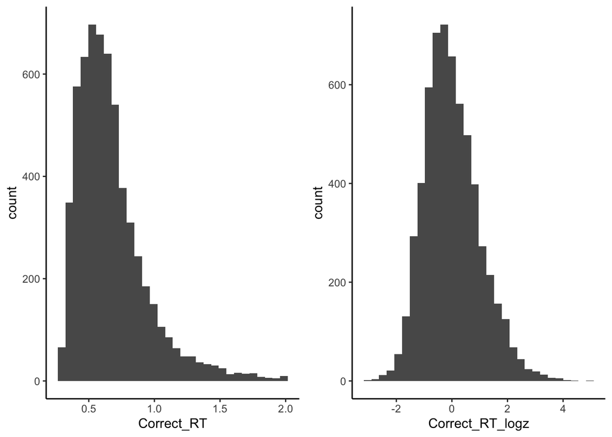

```r
plot1 <- ggplot(rt_data_mod, aes(x=Correct_RT)) + geom_histogram() + theme_classic()

plot2 <- ggplot(rt_data_mod, aes(x=Correct_RT_logz)) + geom_histogram() + theme_classic()

grid.arrange(plot1, plot2, ncol=2)
```

The raw reaction times are not normally distributed and right-skewed. This may be a result of the task design where participants were given a window to view the interest and the peer condition, then a separate window to respond. So all participants were forced to view the condition for the same amount of time. After our log and z-transform, we have a normal distribution for the reaction times.

# Behavioral Analyses

## Run and Reaction Time

Use a linear mixed-effects model to model both the fixed effects of our conditions of interest, and the random effects of the participants. An example of a random effect would be that some participants are just faster to respond in all conditions.

```r
model_run <- lmer(Correct_RT_logz ~ Run + (1 + Run | participant_id),
                data = rt_data_mod)
```

```
## boundary (singular) fit: see help('isSingular')
```

```r
summary(model_run)
```

```
## Linear mixed model fit by REML. t-tests use Satterthwaite's method [
## lmerModLmerTest]
## Formula: Correct_RT_logz ~ Run + (1 + Run | participant_id)
##    Data: rt_data_mod
##
## REML criterion at convergence: 16765.8
##
## Scaled residuals:
##     Min      1Q  Median      3Q     Max
## -3.0842 -0.6970 -0.1243  0.5883  5.4264
##
## Random effects:
##  Groups         Name        Variance Std.Dev. Corr
##  participant_id (Intercept) 0.18137  0.4259
##                 Run         0.02966  0.1722   -1.00
##  Residual                   0.93585  0.9674
## Number of obs: 6007, groups:  participant_id, 78
##
## Fixed effects:
##             Estimate Std. Error       df t value Pr(>|t|)
## (Intercept)  0.21907    0.05790 80.84013   3.784 0.000295 ***
## Run         -0.08929    0.02292 79.91655  -3.896 0.000202 ***
## ---
## Signif. codes:  0 '***' 0.001 '**' 0.01 '*' 0.05 '.' 0.1 ' ' 1
##
## Correlation of Fixed Effects:
##     (Intr)
## Run -0.975
## optimizer (nloptwrap) convergence code: 0 (OK)
## boundary (singular) fit: see help('isSingular')
```

This analysis shows that participants are getting faster at responding throughout the task (B = -0.09, p = .0002).

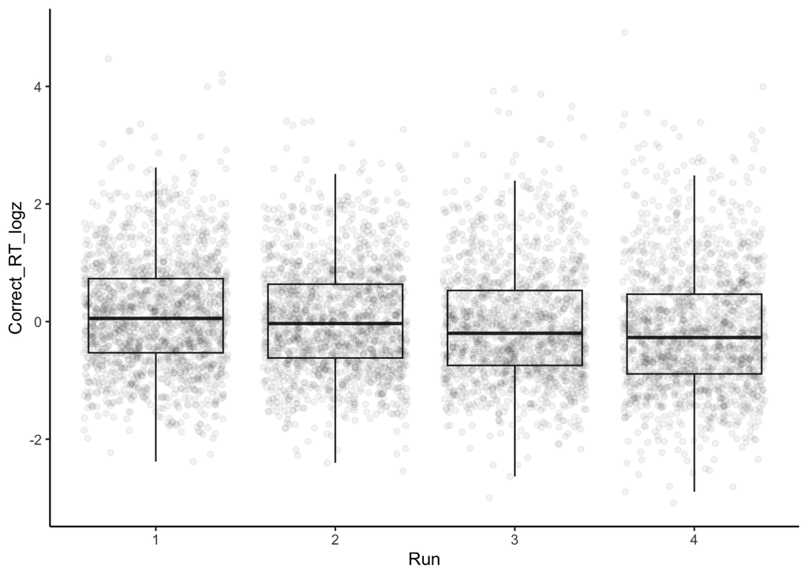

```r
ggplot(data = rt_data_mod, aes(x=Run, y=Correct_RT_logz, group=Run)) +
  geom_boxplot(outlier.shape = NA) +
  geom_jitter(color='black', alpha=0.05) +
  theme_classic()
```

The box plots show this significant tread, and the individual response times for all participants.

## Peer Category and Run Predicting Reaction Time

Next, we will examine whether there are differences in reaction time to our peer conditions throughout the task. Again, the conditions were were getting feedback from a similar peer (75% positive feedback), dissimilar peer (25% positive feedback), or a random computer (50% positive feedback).

```r
model_run_peer <- lmer(Correct_RT_logz ~ Run*Condition + (1 + Run | participant_id),
                       data = rt_data_mod)
```

```
## boundary (singular) fit: see help('isSingular')
```

```r
summary(model_run_peer)
```

```
## Linear mixed model fit by REML. t-tests use Satterthwaite's method [
## lmerModLmerTest]
## Formula: Correct_RT_logz ~ Run * Condition + (1 + Run | participant_id)
##    Data: rt_data_mod
##
## REML criterion at convergence: 16779.7
##
## Scaled residuals:
##     Min      1Q  Median      3Q     Max
## -3.0578 -0.6921 -0.1145  0.5883  5.4759
##
## Random effects:
##  Groups         Name        Variance Std.Dev. Corr
##  participant_id (Intercept) 0.18155  0.4261
##                 Run         0.02969  0.1723   -1.00
##  Residual                   0.93525  0.9671
## Number of obs: 6007, groups:  participant_id, 78
##
## Fixed effects:
##                        Estimate Std. Error         df t value Pr(>|t|)
## (Intercept)             0.17180    0.07167  188.65059   2.397   0.0175 *
## Run                    -0.05709    0.02776  171.15641  -2.057   0.0412 *
## ConditionDisPeer        0.05076    0.07327 5932.66511   0.693   0.4885
## ConditionSimPeer        0.09080    0.07308 5932.93855   1.243   0.2141
## Run:ConditionDisPeer   -0.04220    0.02715 5932.87795  -1.554   0.1201
## Run:ConditionSimPeer   -0.05427    0.02705 5932.95603  -2.006   0.0449 *
## ---
## Signif. codes:  0 '***' 0.001 '**' 0.01 '*' 0.05 '.' 0.1 ' ' 1
##
## Correlation of Fixed Effects:
##             (Intr) Run    CndtDP CndtSP Rn:CDP
## Run         -0.952
## ConditnDsPr -0.510  0.443
## ConditnSmPr -0.511  0.444  0.500
## Rn:CndtnDsP  0.463 -0.488 -0.909 -0.454
## Rn:CndtnSmP  0.465 -0.489 -0.454 -0.909  0.500
## optimizer (nloptwrap) convergence code: 0 (OK)
## boundary (singular) fit: see help('isSingular')
```

Accounting for the peer condition, task run had a significant impact on reaction times (B = -0.06, p = .0412), such that participants were getting faster as the task went on. There was no significant main effect of peer condition. The only interaction that was significant was participants had faster reaction times throughout the task for the similar peer condition, in comparison to the computer control condition (B = -0.05, p = 0.0449).

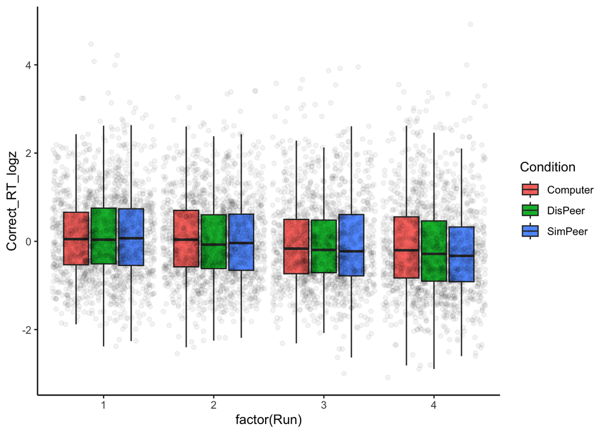

```r
ggplot(data = rt_data_mod, aes(x=factor(Run), y=Correct_RT_logz, fill=Condition)) +
  geom_boxplot(outlier.shape = NA) +
  geom_point(alpha=0.05, aes(fill=Condition),
             position = position_jitterdodge(dodge.width = 0.8)) +
  theme_classic()
```

# Group Analyses

Next, we will analyze run by condition interactions for non-autistic adolescents and autistic adolescents, individually.

## Non-Autistic

```r
rt_data_mod_typ <- filter(rt_data_mod, group == 'non-autistic')
print(paste("There are ",length(unique(rt_data_mod_typ$participant_id)),
            " non-autistic participants"))
```

```
## [1] "There are  54  non-autistic participants"
```

```r
model_run_peer_typ <- lmer(Correct_RT_logz ~ Run*Condition + (1 + Run | participant_id ), data = rt_data_mod_typ)
```

```
## boundary (singular) fit: see help('isSingular')
```

```r
summary(model_run_peer_typ)
```

```
## Linear mixed model fit by REML. t-tests use Satterthwaite's method [
## lmerModLmerTest]
## Formula: Correct_RT_logz ~ Run * Condition + (1 + Run | participant_id)
##    Data: rt_data_mod_typ
##
## REML criterion at convergence: 11123.5
##
## Scaled residuals:
##     Min      1Q  Median      3Q     Max
## -3.0497 -0.6742 -0.1058  0.5895  5.5140
##
## Random effects:
##  Groups         Name        Variance Std.Dev. Corr
##  participant_id (Intercept) 0.19468  0.4412
##                 Run         0.03168  0.1780   -1.00
##  Residual                   0.92463  0.9616
## Number of obs: 3995, groups:  participant_id, 54
##
## Fixed effects:
##                        Estimate Std. Error         df t value Pr(>|t|)
## (Intercept)             0.19632    0.08899  126.91773   2.206   0.0292 *
## Run                    -0.06078    0.03447  115.90974  -1.763   0.0805 .
## ConditionDisPeer        0.11405    0.08992 3943.47659   1.268   0.2047
## ConditionSimPeer        0.11316    0.08983 3943.65498   1.260   0.2078
## Run:ConditionDisPeer   -0.07895    0.03337 3943.58963  -2.366   0.0180 *
## Run:ConditionSimPeer   -0.06979    0.03328 3943.65058  -2.097   0.0361 *
## ---
## Signif. codes:  0 '***' 0.001 '**' 0.01 '*' 0.05 '.' 0.1 ' ' 1
##
## Correlation of Fixed Effects:
##             (Intr) Run    CndtDP CndtSP Rn:CDP
## Run         -0.954
## ConditnDsPr -0.504  0.439
## ConditnSmPr -0.504  0.439  0.499
## Rn:CndtnDsP  0.458 -0.482 -0.910 -0.454
## Rn:CndtnSmP  0.459 -0.483 -0.454 -0.910  0.499
## optimizer (nloptwrap) convergence code: 0 (OK)
## boundary (singular) fit: see help('isSingular')
```

In non-autistic adolescents, there was not a significant main effect of run, indicating that participants did not get faster at responding as the task went on (b = -0.06, p = .0805). There were two significant interactions. Non-autistic adolescents had significantly faster reaction times as the task went on for the dissimilar peer (B = -0.08, p = .018) and the similar peer (B = -0.07, p = .0361) conditions compared to the control condition.

```r
m.lst <- emtrends(model_run_peer_typ, "Condition", var="Run")
```

[output not shown]

[output not shown]

```r
pairs(m.lst)
```

```
##  contrast           estimate     SE  df z.ratio p.value
##  Computer - DisPeer  0.07895 0.0334 Inf   2.366  0.0472
##  Computer - SimPeer  0.06979 0.0333 Inf   2.097  0.0904
##  DisPeer - SimPeer  -0.00916 0.0334 Inf  -0.275  0.9593
##
## Degrees-of-freedom method: asymptotic
## P value adjustment: tukey method for comparing a family of 3 estimates
```

There was no significant difference between the similar peer and dissimilar peer condition by run interaction. Weird that the computer vs similar peer contrast is not significant here though…

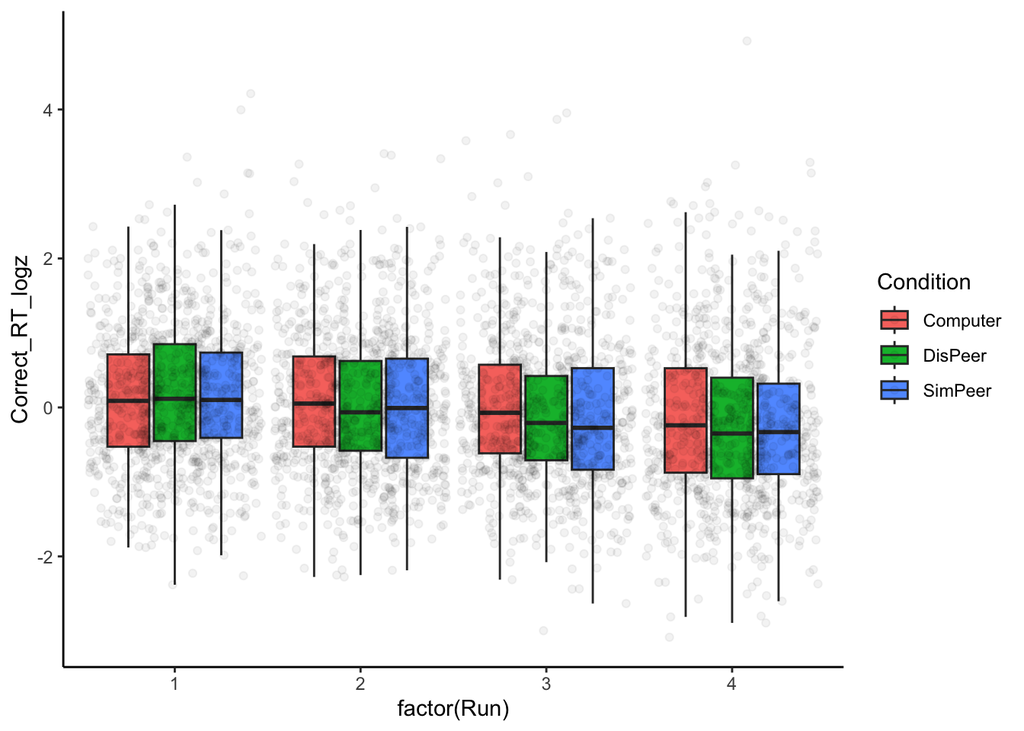

```r
ggplot(data = rt_data_mod_typ, aes(x=factor(Run), y=Correct_RT_logz,
                                   fill=Condition)) +
  geom_boxplot(outlier.shape = NA) +
  geom_point(alpha=0.05, aes(fill=Condition),
             position = position_jitterdodge(dodge.width = 0.8)) +
  theme_classic()
```

## Autistic

```r
rt_data_mod_asd <- filter(rt_data_mod, group == 'autistic')
print(paste("There are ",length(unique(rt_data_mod_asd$participant_id)),
            " autistic participants"))
```

```
## [1] "There are  24  autistic participants"
```

```r
model_run_peer_asd <- lmer(Correct_RT_logz ~ Run*Condition + (1 + Run | participant_id), data = rt_data_mod_asd)
```

```
## boundary (singular) fit: see help('isSingular')
```

```r
summary(model_run_peer_asd)
```

```
## Linear mixed model fit by REML. t-tests use Satterthwaite's method [
## lmerModLmerTest]
## Formula: Correct_RT_logz ~ Run * Condition + (1 + Run | participant_id)
##    Data: rt_data_mod_asd
##
## REML criterion at convergence: 5673.5
##
## Scaled residuals:
##     Min      1Q  Median      3Q     Max
## -2.6173 -0.7303 -0.1506  0.5802  4.1777
##
## Random effects:
##  Groups         Name        Variance Std.Dev. Corr
##  participant_id (Intercept) 0.14443  0.3800
##                 Run         0.02408  0.1552   -1.00
##  Residual                   0.95636  0.9779
## Number of obs: 2012, groups:  participant_id, 24
##
## Fixed effects:
##                        Estimate Std. Error         df t value Pr(>|t|)
## (Intercept)             0.11541    0.11845   62.18304   0.974    0.334
## Run                    -0.04668    0.04586   55.08616  -1.018    0.313
## ConditionDisPeer       -0.06643    0.12644 1983.93879  -0.525    0.599
## ConditionSimPeer        0.05003    0.12569 1983.99969   0.398    0.691
## Run:ConditionDisPeer    0.02724    0.04669 1984.05155   0.583    0.560
## Run:ConditionSimPeer   -0.02482    0.04645 1984.03551  -0.534    0.593
##
## Correlation of Fixed Effects:
##             (Intr) Run    CndtDP CndtSP Rn:CDP
## Run         -0.947
## ConditnDsPr -0.532  0.460
## ConditnSmPr -0.535  0.463  0.501
## Rn:CndtnDsP  0.482 -0.509 -0.906 -0.455
## Rn:CndtnSmP  0.485 -0.511 -0.454 -0.906  0.502
## optimizer (nloptwrap) convergence code: 0 (OK)
## boundary (singular) fit: see help('isSingular')
```

In autistic adolescents, there are no significant main effects or interactions.

```r
m.lst <- emtrends(model_run_peer_asd, "Condition", var="Run")
pairs(m.lst)
```

```
##  contrast           estimate     SE   df t.ratio p.value
##  Computer - DisPeer  -0.0272 0.0467 1963  -0.583  0.8290
##  Computer - SimPeer   0.0248 0.0465 1963   0.534  0.8544
##  DisPeer - SimPeer    0.0521 0.0465 1964   1.120  0.5016
##
## Degrees-of-freedom method: kenward-roger
## P value adjustment: tukey method for comparing a family of 3 estimates
```

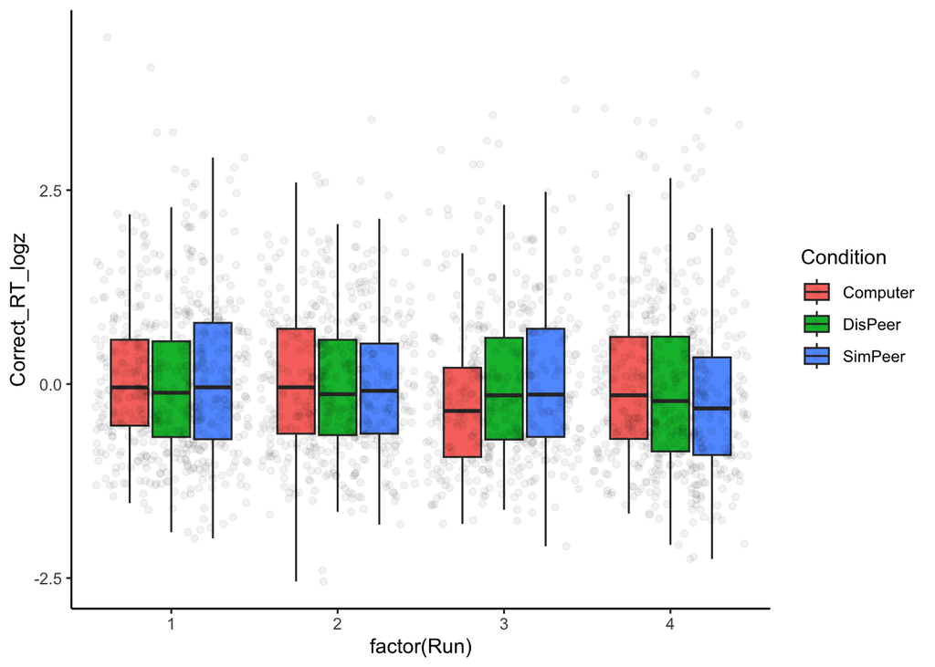

```r
ggplot(data = rt_data_mod_asd, aes(x=factor(Run), y=Correct_RT_logz,
                                   fill=Condition)) +
  geom_boxplot(outlier.shape = NA) +
  geom_point(alpha=0.05, aes(fill=Condition),
             position = position_jitterdodge(dodge.width = 0.8)) +
  theme_classic()
```

## Autistic vs Non-Autistic

In this analysis, we will examine specific contrasts between autistic and non-autistic adolescents. For example, we will test whether there are any group differences in reaction times for similar peers and the computer condition, throughout the task.